# Homework 3

### Loading Libraries

```r
library(tidyverse)
```

### Formatting plots

```r
knitr::opts_chunk$set(
  fig.width = 15,
  fig.asp = .6,
  out.width = "90%")

theme_set(theme_minimal() + theme(legend.position = "bottom"))

options(
  ggplot2.continuous.colour = "viridis",
  ggplot2.continuous.colour = "viridis")

sclae_colour_discrete = scale_color_viridis_d
scale_fill_discrete = scale_fill_viridis_d
```

# Problem 1

```r
library(p8105.datasets)
data("instacart")
```

### Instacart Dataset Descriptions

- The Instacart dataset includes 15 variables: order_id, product_id, add_to_cart_order, reordered, user_id, eval_set, order_number, order_dow, order_hour_of_day, days_since_prior_order, product_name, aisle_id, department_id, aisle, department.
- The dataset has 1384617 rows and 15 columns.
- The number of observations is 1384617.
- The range of days since the prior order is (0, 30).
- The median number of items added to cart order is (7).
- The total number of times an item was reordered is 828824.

### Aisles: Count and Most Ordered

```r
instacart %>%
  summarize(distinct_aisles = n_distinct(aisle))
```

```
## # A tibble: 1 × 1
##   distinct_aisles
##             <int>
## 1             134
```

- There are 134 different aisles.

### Creating a plot

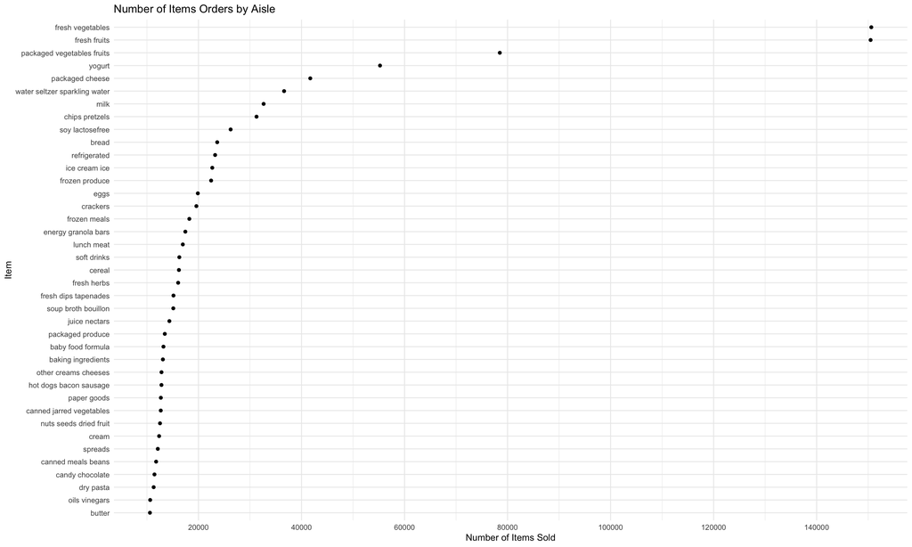

```r
instacart %>%
  count(aisle) %>%
  filter(n > 10000) %>%
  mutate(
    aisle = factor(aisle),
    aisle = fct_reorder(aisle, n)) %>%
  ggplot(aes(x = n, y = aisle)) +
  geom_point() +
  labs(
    title = "Number of Items Orders by Aisle",
    x = "Number of Items Sold",
    y = "Item") +
  scale_x_continuous(
    breaks = c(20000, 40000, 60000, 80000, 100000, 120000, 140000))
```

* The aisles where the most items are ordered from are 83 for fresh vegetables, 24 for fresh fruits, and 123 for packaged vegetables fruits.

### Instacart: Cleaning and filter

```r
popular_items = instacart %>%
  filter(aisle %in% c("baking ingredients", "dog food care", "packaged vegetables fruits")) %>%
  group_by(aisle) %>%
  count(product_name) %>%
  mutate(rank = min_rank(desc(n))) %>%
  filter(rank < 4)
```

### Instacart: Table

```r
knitr::kable(head(popular_items[, 1:4]), "simple")
```

| aisle | product_name | n | rank |
| --- | --- | --- | --- |
| baking ingredients | Cane Sugar | 336 | 3 |
| baking ingredients | Light Brown Sugar | 499 | 1 |
| baking ingredients | Pure Baking Soda | 387 | 2 |
| dog food care | Organix Chicken & Brown Rice Recipe | 28 | 2 |
| dog food care | Small Dog Biscuits | 26 | 3 |
| dog food care | Snack Sticks Chicken & Rice Recipe Dog Treats | 30 | 1 |

### Icecream: Cleaning and filtering

```r
applies_icecream = instacart %>%
  filter(product_name %in% c("Pink Lady Apples", "Coffee Ice Cream")) %>%
  mutate(
    order_dow = recode(order_dow,
                       "0" = "Sunday",
                       "1" = "Monday",
                       "2" = "Tuesday",
                       "3" = "Wednesday",
                       "4" = "Thursday",
                       "5" = "Friday",
                       "6" = "Saturday")) %>%
  group_by(product_name, order_dow) %>%
  summarize(mean_hour = mean(order_hour_of_day)) %>%
  pivot_wider(
    names_from = order_dow,
    values_from = mean_hour
  )
```

### Icecream: Table

```r
knitr::kable(head(applies_icecream[, 1:8]), "simple")
```

| product_name | Friday | Monday | Saturday | Sunday | Thursday | Tuesday | Wednesday |
| --- | --- | --- | --- | --- | --- | --- | --- |
| Coffee Ice Cream | 12.26316 | 14.31579 | 13.83333 | 13.77419 | 15.21739 | 15.38095 | 15.31818 |
| Pink Lady Apples | 12.78431 | 11.36000 | 11.93750 | 13.44118 | 11.55172 | 11.70213 | 14.25000 |

# Problem 2

```r
library(p8105.datasets)
data("brfss_smart2010")
```

### Cleaning Data

```r
brfss_smart20102 = brfss_smart2010 %>%
  janitor::clean_names() %>%
  mutate(response = str_to_lower(response),
         response = recode(response,
                            "very good" = "very_good")) %>%
  filter(topic == "Overall Health",
         response %in% c("excellent", "very_good", "good", "poor")) %>%
  mutate(response = factor(response, levels = c("excellent", "very_good", "good", "poor")))
```

### 2002 states with 7 or more locations

```r
states_2002 = brfss_smart20102 %>%
  filter(year == 2002) %>%
  count(locationabbr) %>%
  filter(n >= 7)
```

- The following states observed 7 or more locations in 2002: AZ, CO, CT, DE, FL, GA, HI, ID, IL, IN, KS, LA, MA, MD, ME, MI, MN, MO, NC, NE, NH, NJ, NV, NY, OH, OK, OR, PA, RI, SC, SD, TN, TX, UT, VT, WA.

### 2010 states with 7 or more locations

```r
states_2010 = brfss_smart20102 %>%
  filter(year == 2010) %>%
  count(locationabbr) %>%
  filter(n >= 7)
```

- The following states observed 7 or more locations in 2010: AL, AR, AZ, CA, CO, CT, DE, FL, GA, HI, IA, ID, IL, IN, KS, LA, MA, MD, ME, MI, MN, MO, MS, MT, NC, ND, NE, NH, NJ, NM, NV, NY, OH, OK, OR, PA, RI, SC, SD, TN, TX, UT, VT, WA, WY.

### String plot of excellent responses

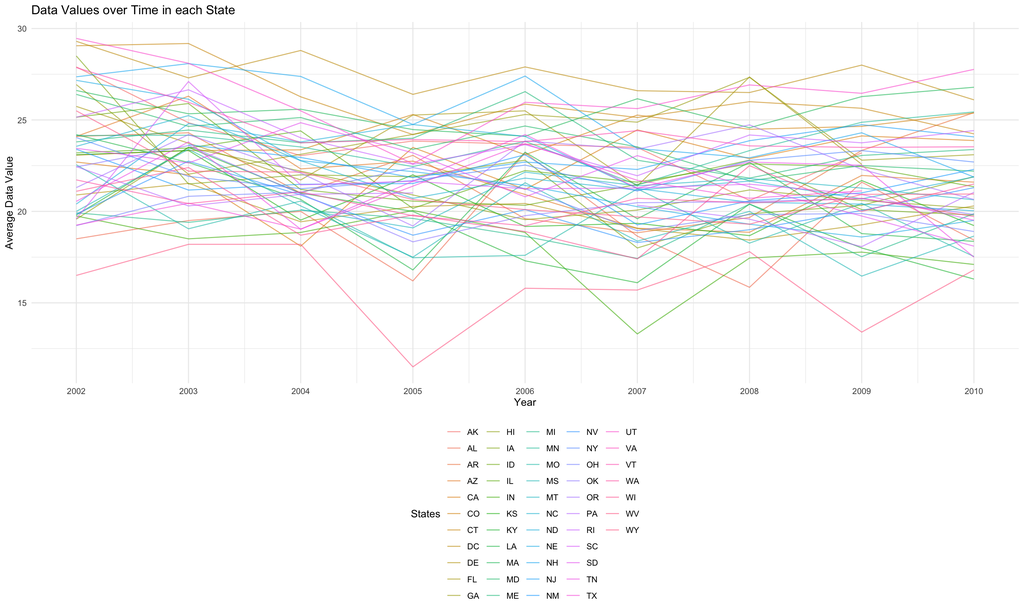

```r
excellent = brfss_smart20102 %>%
  filter(response == "excellent") %>%
  group_by(locationabbr, year) %>%
  mutate(average_data_value = mean(data_value)) %>%
  select(year, average_data_value, locationabbr) %>%
  ggplot(aes(x = year, y = average_data_value, group = locationabbr, color = locationabbr)) +
  geom_line(alpha = .6) +
    labs(
    title = "Data Values over Time in each State",
    x = "Year",
    y = "Average Data Value",
    colour = "States"
  ) +
  scale_x_continuous(
    breaks = c(2002:2010))

excellent
```

- The plot shows that the average data values tends to decrease over time for most states. The average data values are typically around 22.5.

### Distribution Plot

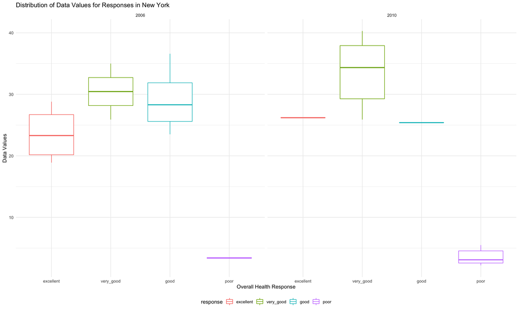

```r
plot_data = brfss_smart20102 %>%
  filter(locationabbr == "NY") %>%
  filter(year == c(2006,2010)) %>%
  ggplot(aes(x = response, y = data_value, color = response)) +
  geom_boxplot() +
  facet_grid(. ~ year) +
  labs(
    title = "Distribution of Data Values for Responses in New York",
    x = "Overall Health Response",
    y = "Data Values"
  )

plot_data
```

- The data values for for excellent, very good, and good are much higher than the data values for poor.

# Problem 3

```r
accel = read_csv(file = "data/accel_data.csv")
```

### Accelerometer Dataset Cleaning

```r
clean_accel = accel %>%
  janitor::clean_names() %>%
  mutate(week_day = ifelse(day %in% c("Saturday", "Sunday"), "weekday", "weekend")) %>%
  select(week_day, everything()) %>%
  pivot_longer(
    activity_1:activity_1440,
    names_to = "activity_day",
    values_to = "activity_counts")
```

### Accelerometer Dataset Description

- The Accelerometer dataset includes variables week_day, week, day_id, day, and activity.
- The dataset has 35 rows and 1443 columns.
- The number of observations is 35.
- The mean amount of activity over the study period is 267.0440592.

### Aggregating Accelerometer Dataset

```r
clean_accel2 = clean_accel %>%
  group_by(day_id, day) %>%
  summarize(sum_activity = sum(activity_counts))
```

### Table of Activity Counter per Day

```r
knitr::kable(clean_accel2)
```

| day_id | day | sum_activity |
| --- | --- | --- |
| 1 | Friday | 480542.62 |
| 2 | Monday | 78828.07 |
| 3 | Saturday | 376254.00 |
| 4 | Sunday | 631105.00 |
| 5 | Thursday | 355923.64 |
| 6 | Tuesday | 307094.24 |
| 7 | Wednesday | 340115.01 |
| 8 | Friday | 568839.00 |
| 9 | Monday | 295431.00 |
| 10 | Saturday | 607175.00 |
| 11 | Sunday | 422018.00 |
| 12 | Thursday | 474048.00 |
| 13 | Tuesday | 423245.00 |
| 14 | Wednesday | 440962.00 |
| 15 | Friday | 467420.00 |
| 16 | Monday | 685910.00 |
| 17 | Saturday | 382928.00 |
| 18 | Sunday | 467052.00 |
| 19 | Thursday | 371230.00 |
| 20 | Tuesday | 381507.00 |
| 21 | Wednesday | 468869.00 |
| 22 | Friday | 154049.00 |
| 23 | Monday | 409450.00 |
| 24 | Saturday | 1440.00 |
| 25 | Sunday | 260617.00 |
| 26 | Thursday | 340291.00 |
| 27 | Tuesday | 319568.00 |
| 28 | Wednesday | 434460.00 |
| 29 | Friday | 620860.00 |
| 30 | Monday | 389080.00 |
| 31 | Saturday | 1440.00 |
| 32 | Sunday | 138421.00 |
| 33 | Thursday | 549658.00 |
| 34 | Tuesday | 367824.00 |
| 35 | Wednesday | 445366.00 |

- While during the first half of the study period, the activity counts are high during weekends, the second half of the study period shows lower activity counts on the weekend. The counts per day typically stay around 400,000. The lowest levels of activity occur on day 24 and 31.

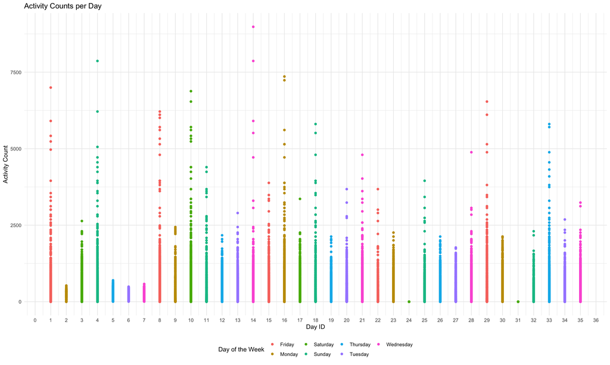

```r
ggplot(clean_accel, aes(x = day_id, y = activity_counts, color = day)) +
  geom_point() +
  labs(
    title = "Activity Counts per Day",
    x = "Day ID",
    y = "Activity Count",
    colour = "Day of the Week"
  ) +
  scale_x_continuous(
    breaks = c(0:36))
```